# 02 - Customizing Seaborn Plots

```python
import matplotlib.pyplot as plt
import pandas as pd
import seaborn as sns
import numpy as np

df2 = pd.read_csv("/home/cla/Documentos/Vitor/DataCamp/Data-Scientist-with-Python/Datasets/2018-College-Scorecard-Tuition.csv")

df = pd.read_csv("/home/cla/Documentos/Vitor/DataCamp/Data-Scientist-with-Python/Datasets/US-Housing-and-Urban-Development-FY-2018-Fair-Market-Rent.csv")

median = df.fmr_1.median()
mean = df.fmr_1.mean()
```

## **Using Seaborn Styles**

**1. Using Seaborn Styles**

Choosing the right type of plot is only the first step in creating effective visualizations. It is also important to configure the other aspects of your visualizations such as the layouts, labels, and colors. These traits are referred to as the visualization’s aesthetics. Seaborn provides many functions for configuring your plots so they have the most impact. In this lesson, we will cover how to use Seaborn’s style functions to dramatically alter the way your data is displayed.

**2. Setting Styles**

Seaborn has several default built in themes that are more appealing than the default matplotlib styles. In order to set a default theme, use the sns.set() function. In this example, we can look at the distribution of college tuition fees in the US. The first image shows the standard pandas histogram and the second plot shows what the histogram looks like with Seaborn’s style. Notice how the color palette is muted and the grid lines are displayed. This is the default Seaborn style, also called darkgrid.

```python
reticulate::repl_python()
```

```
Python 3.6.11 (/home/cla/.local/share/r-miniconda/envs/r-reticulate/bin/python)
Reticulate 1.18 REPL -- A Python interpreter in R.
```

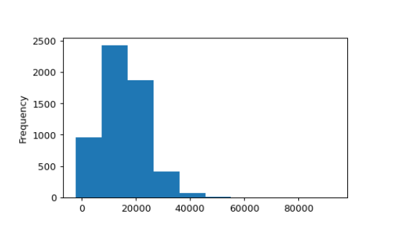

```python
fig, ax = plt.subplots()
_ = fig.tight_layout(pad = 5)
df2['Tuition'].plot.hist()
plt.show()
```

```python
pl.clf()
```

[output not shown]

```python
reticulate::repl_python()
```

```
Python 3.6.11 (/home/cla/.local/share/r-miniconda/envs/r-reticulate/bin/python)
Reticulate 1.18 REPL -- A Python interpreter in R.
```

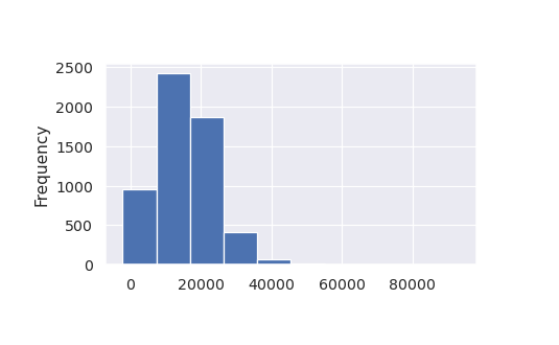

```python
sns.set()
fig, ax = plt.subplots()
_ = fig.tight_layout(pad = 5)
df2['Tuition'].plot.hist()
plt.show()
```

```python
pl.clf()
```

[output not shown]

**3. Theme examples with sns.set_style()**

Styles control multiple aspects of the final plot including the color palette and the use of grid lines or tick marks. Depending on the visualization, one style may be more beneficial than others for conveying your message. The best approach is to experiment with the styles and use the one that works best for your needs. This example shows the impact changing styles can have when plotting your data.

```python
reticulate::repl_python()
```

```
Python 3.6.11 (/home/cla/.local/share/r-miniconda/envs/r-reticulate/bin/python)
Reticulate 1.18 REPL -- A Python interpreter in R.
```

[figure not shown]

[figure not shown]

[figure not shown]

[figure not shown]

[figure not shown]

```python
for style in ['white', 'dark', 'whitegrid', 'darkgrid', 'ticks']:
  _ = sns.set_style(style)
  _ = sns.distplot(df2['Tuition'])
  plt.show()
plt.clf()
```

```python
reticulate::repl_python()
```

```
Python 3.6.11 (/home/cla/.local/share/r-miniconda/envs/r-reticulate/bin/python)
Reticulate 1.18 REPL -- A Python interpreter in R.
```

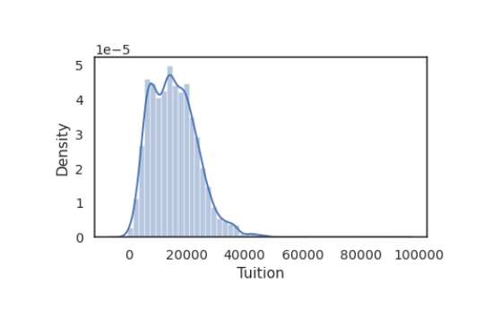

```python
_ = sns.set_style('white')
_ = sns.distplot(df2['Tuition'])
plt.show()
```

```python
plt.clf()
```

```python
reticulate::repl_python()
```

```
Python 3.6.11 (/home/cla/.local/share/r-miniconda/envs/r-reticulate/bin/python)
Reticulate 1.18 REPL -- A Python interpreter in R.
```

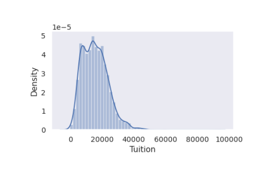

```python
_ = sns.set_style('dark')
_ = sns.distplot(df2['Tuition'])
plt.show()
```

```python
plt.clf()
```

```python
reticulate::repl_python()
```

```
Python 3.6.11 (/home/cla/.local/share/r-miniconda/envs/r-reticulate/bin/python)
Reticulate 1.18 REPL -- A Python interpreter in R.
```

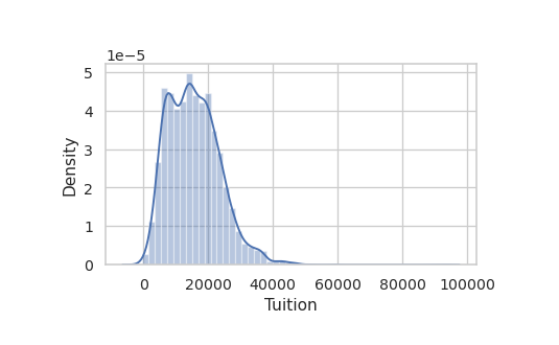

```python
_ = sns.set_style('whitegrid')
_ = sns.distplot(df2['Tuition'])
plt.show()
```

```python
plt.clf()
```

```python
reticulate::repl_python()
```

```
Python 3.6.11 (/home/cla/.local/share/r-miniconda/envs/r-reticulate/bin/python)
Reticulate 1.18 REPL -- A Python interpreter in R.
```

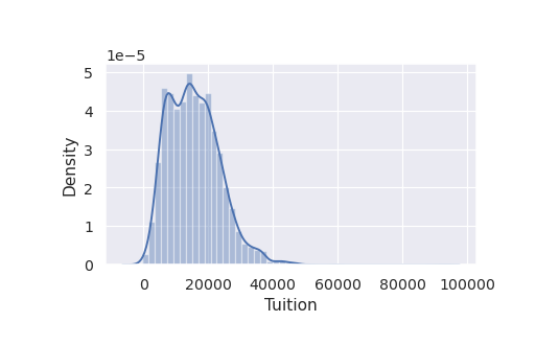

```python
_ = sns.set_style('darkgrid')
_ = sns.distplot(df2['Tuition'])
plt.show()
```

```python
plt.clf()
```

```python
reticulate::repl_python()
```

```
Python 3.6.11 (/home/cla/.local/share/r-miniconda/envs/r-reticulate/bin/python)
Reticulate 1.18 REPL -- A Python interpreter in R.
```

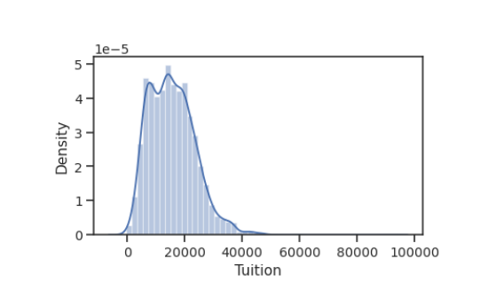

```python
_ = sns.set_style('ticks')
_ = sns.distplot(df2['Tuition'])
plt.show()
```

```python
plt.clf()
```

**4. Removing axes with despine()**

In general, visualizations are more impactful if the amount of excess “chart junk” is removed. A common use case is to remove the lines around the axes called spines. Seaborn’s despine() function removes one or more of the spines on a chart. The default is to remove the top and right lines but more can be removed by passing arguments to the despine() function.

```python
reticulate::repl_python()
```

```
Python 3.6.11 (/home/cla/.local/share/r-miniconda/envs/r-reticulate/bin/python)
Reticulate 1.18 REPL -- A Python interpreter in R.
```

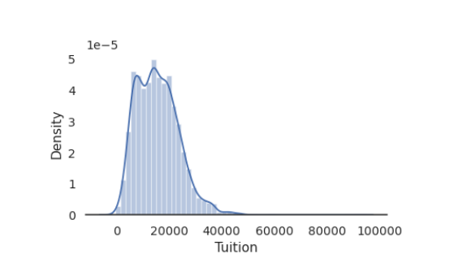

```python
_ = sns.set_style('white')
_ = sns.distplot(df2['Tuition'])
_ = sns.despine(left = True)
plt.show()
```

```python
plt.clf()
```

**5. Let’s practice!**

Now that you have learned about some simple methods for modifying the aesthetics of your plots, let’s try some examples on your own.

### **Setting the default style**

For these exercises, we will be looking at fair market rent values calculated by the US Housing and Urban Development Department. This data is used to calculate guidelines for several federal programs. The actual values for rents vary greatly across the US. We can use this data to get some experience with configuring Seaborn plots.

All of the necessary imports for `seaborn`, `pandas` and `matplotlib` have been completed. The data is stored in the pandas DataFrame `df`.

*By the way, if you haven’t downloaded it already, check out the [Seaborn Cheat Sheet](https://datacamp-community-prod.s3.amazonaws.com/f9f06e72-519a-4722-9912-b5de742dbac4). It includes an overview of the most important concepts, functions and methods and might come in handy if you ever need a quick refresher!*

**Instructions**

- Plot a `pandas` histogram without adjusting the style.
- Set Seaborn’s default style.
- Create another `pandas` histogram of the `fmr_2` column which represents fair market rent for a 2-bedroom apartment.

```python
reticulate::repl_python()
```

```
Python 3.6.11 (/home/cla/.local/share/r-miniconda/envs/r-reticulate/bin/python)
Reticulate 1.18 REPL -- A Python interpreter in R.
```

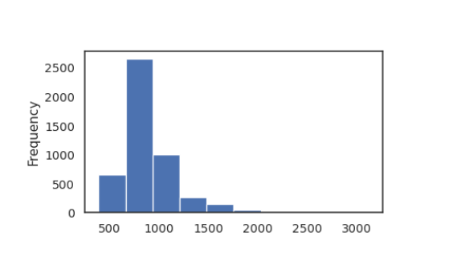

```python
# Plot the pandas histogram
df['fmr_2'].plot.hist()
plt.show()
```

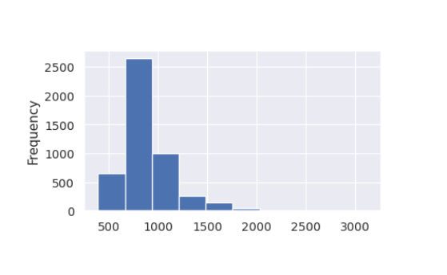

```python
plt.clf()

# Set the default seaborn style
sns.set()

# Plot the pandas histogram again
df['fmr_2'].plot.hist()
plt.show()
```

```python
plt.clf()
```

You can see how the histogram is changed when the Seaborn style is applied to the underlying visualization.

### **Comparing styles**

Seaborn supports setting different styles that can control the aesthetics of the final plot. In this exercise, you will plot the same data in two different styles in order to see how the styles change the output.

**Instructions**

1. Create a `distplot()` of the `fmr_2` column in `df` using a dark style. Use `plt.clf()` to clear the figure.
2. Create the same `distplot()` of `fmr_2` using a whitegrid style. Clear the plot after showing it.

```python
reticulate::repl_python()
```

```
Python 3.6.11 (/home/cla/.local/share/r-miniconda/envs/r-reticulate/bin/python)
Reticulate 1.18 REPL -- A Python interpreter in R.
```

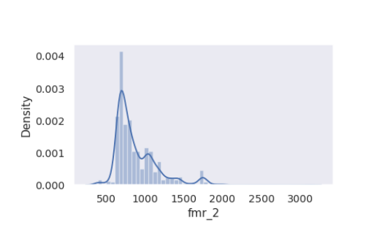

```python
_ = sns.set_style('dark')
_ = sns.distplot(df['fmr_2'])
plt.show()
```

```python
plt.clf()
```

```python
reticulate::repl_python()
```

```
Python 3.6.11 (/home/cla/.local/share/r-miniconda/envs/r-reticulate/bin/python)
Reticulate 1.18 REPL -- A Python interpreter in R.
```

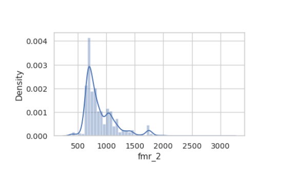

```python
_ = sns.set_style('whitegrid')
_ = sns.distplot(df['fmr_2'])
plt.show()
```

```python
plt.clf()
```

Seaborn’s styles provide a quick and easy way to alter your visualizations in a consistent and visually appealing manner.

### **Removing spines**

In general, visualizations should minimize extraneous markings so that the data speaks for itself. Seaborn allows you to remove the lines on the top, bottom, left and right axis, which are often called spines.

**Instructions**

- Use a white style for the plot.
- Create a `lmplot()` comparing the `pop2010` and the `fmr_2` columns.
- Remove the top and right spines using `despine()`.

```python
reticulate::repl_python()
```

```
Python 3.6.11 (/home/cla/.local/share/r-miniconda/envs/r-reticulate/bin/python)
Reticulate 1.18 REPL -- A Python interpreter in R.
```

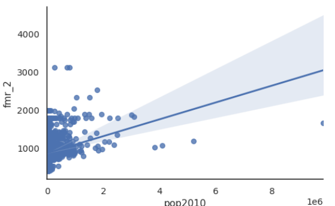

```python
# Set the style to white
sns.set_style('white')

# Create a regression plot
sns.lmplot(data = df,
           x = 'pop2010',
           y = 'fmr_2')
# Remove the spines
sns.despine(top = True, right = True)

# Show the plot and clear the figure
plt.show()
```

```python
plt.clf()
```

Removing the spines lets the data speak for itself.

## **Colors in Seaborn**

**1. Colors in Seaborn**

Color is an extremely important component in creating effective visualizations. Different types of data can be interpreted more effectively by using the correct color palettes. In addition, around 8% of the population is affected by color blindness of some form, so using palettes that are tailored to those users is very important. Seaborn has several functions for creating, viewing, and configuring color palettes. Effectively understanding and using these functions can greatly increase the impact of your plots.

**2. Defining a color for a plot**

Since Seaborn is built on top of matplotlib, it is able to interpret and apply matplotlib color codes. By using the familiar sns.set() function with color codes equals True, any matplotlib color codes will be appropriately mapped to the Seaborn palette. Here is an example of plotting our distplot() using ‘g’ for green.

```python
reticulate::repl_python()
```

```
Python 3.6.11 (/home/cla/.local/share/r-miniconda/envs/r-reticulate/bin/python)
Reticulate 1.18 REPL -- A Python interpreter in R.
```

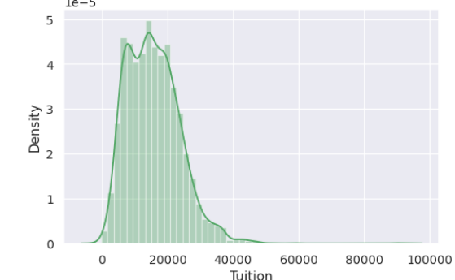

```python
_ = sns.set(color_codes = True)
_ = sns.distplot(df2['Tuition'], color = 'g')
plt.show()
```

```python
plt.clf()
```

**3. Palettes**

As shown in the previous slide, we can assign specific colors to a plot. However, this can be tedious when there are many items that must be encoded with color. Seaborn makes this task much easier by allowing us to set a palette of colors that can be cycled through in a plot. Seaborn has six default palettes including deep, muted, pastel, bright, dark, and colorblind. Here are examples of how the different palettes look with a distplot().

```python
reticulate::repl_python()
```

```
Python 3.6.11 (/home/cla/.local/share/r-miniconda/envs/r-reticulate/bin/python)
Reticulate 1.18 REPL -- A Python interpreter in R.
```

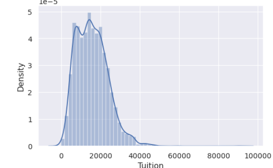

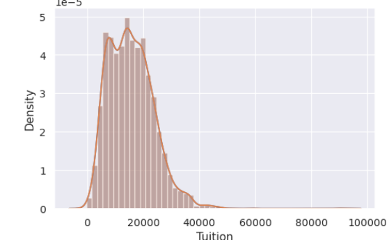

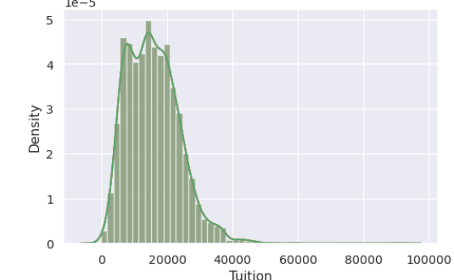

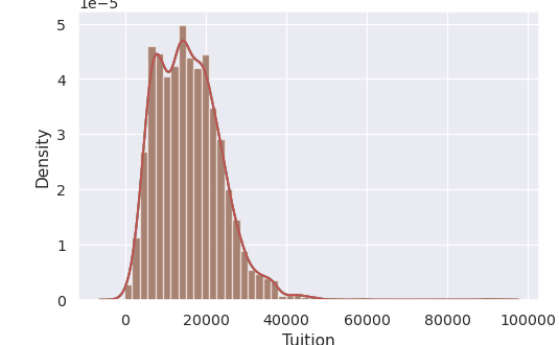

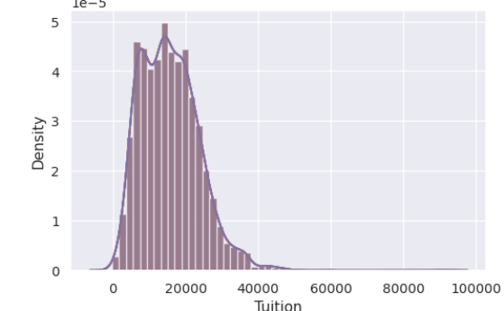

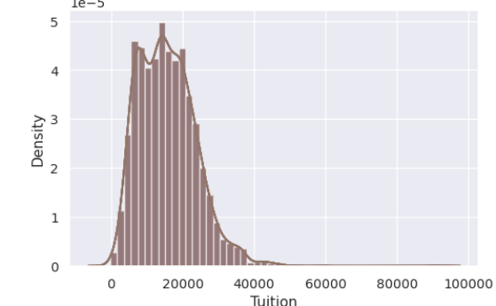

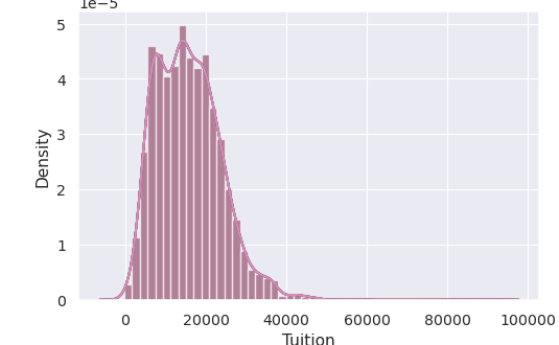

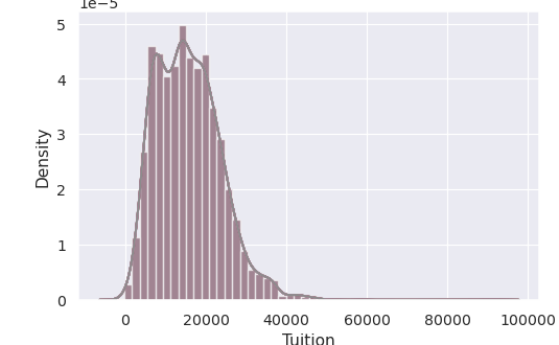

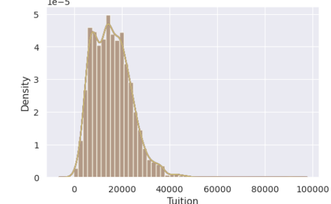

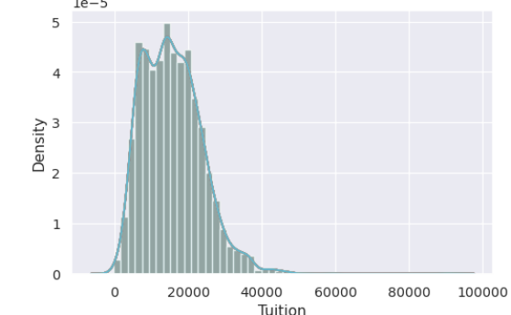

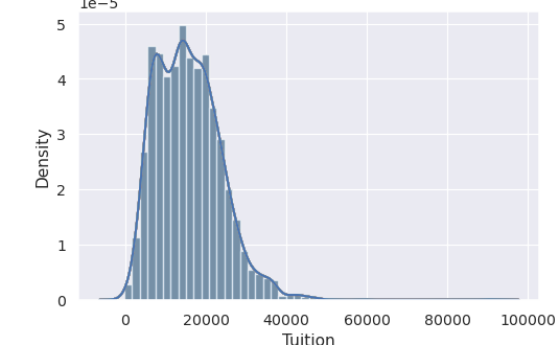

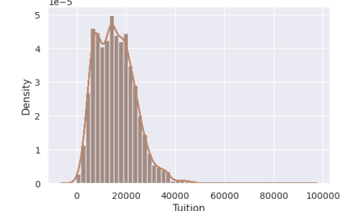

```python
for p in sns.palettes.SEABORN_PALETTES:
  _ = sns.set_palette(p)
  _ = sns.distplot(df2['Tuition'])
  plt.show()
plt.clf()
```

**4. Displaying Palettes**